# Epidemiologický model Covid19 pomocí stochastického SIR modelu

Jan Smyčka

19/3/2020

V souvislosti s šířením nového koronaviru se objevuje velké množství predikcí šíření v Česku založených na SIR epidemiologickém modelu (viz https://en.wikipedia.org/wiki/Compartmental_models_in_epidemiology). Žádný z nich však v současné době nepracuje explicitně s pravděpodobnostní obálkou predikcí. Stejně tak, žádný z nich nemá plně přístupný a uživatelsky přívětivý kód umožňující modelování dopadu různých opatření v čase. V tomto dokumentu představuji predikce stochastického SIR modelu založeného na kódu epidemiologů ze Song Lab na University of Michigan (https://github.com/lilywang1988/eSIR, https://www.medrxiv.org/content/10.1101/2020.02.29.20029421v1.full.pdf). Tento bayesiánský model odhaduje věrohodnost parametrů SIR modelu na základě dat z časových řad pomocí Runge-Kutta aproximace čtvrtého řádu a kromě latentní stochastické SIR vrstvy obsahuje ještě observační vrstvu zohledňující, že počty diagnostikovaných případů jsou pouze zatíženým odhadem počtu všech případů v populaci.

Dokument představuje predikce šíření Covid19 v české populaci na základě dostupných časových řad nakažených a vyléčených (https://cs.wikipedia.org/wiki/Pandemie_COVID-19_v_%C4%8Cesku) a pracuje se sedmi scénáři:

1. šíření bez přijatých opatření
2. šíření za předpokladu že nouzový stav přijatý 13.3. omezí rychlost šíření na 3/4 (R0>1) a bude trvat do konce simulace
3. šíření za předpokladu že nouzový stav přijatý 13.3. omezí rychlost šíření na 1/4 (R0<1)a bude trvat do konce simulace
4. šíření za předpokladu, že nouzový stav omezí rychlost šíření na 1/4 bude zrušen za 1 měsíc
5. šíření za předpokladu, že nouzový stav omezí rychlost šíření na 1/4 a bude zrušen za 3 měsíce
6. šíření za předpokladu, že nouzový stav omezí rychlost šíření na 1/4 a bude periodicky zapínán a vypínán s periodou 1 měsíc
7. šíření za předpokladu, že nouzový stav omezí rychlost šíření na 1/4 ale bude lineárně oslabován (nebo bojkotován populací).

Všechny scénáře počítají s Českem jako s ostrovním systémem až do ukončení simulace, tzn. s absolutním uzavřením hranic případně efektivní izolací migrujících jedinců.

**Při interpretaci výsledků je třeba brát v úvahu, že nespacializované SIR modely jsou pouze velmi hrubou aproximací reality, v našem případě navíc napasovanou na chybou zatížených datech. Kromě toho, odhad, že opatření zavedená 13.3. povedou k omezení rychlosti šíření na 3/4 nebo 1/4 je čistě arbitrární. Ostatně, z intervalů kredibility většiny scénářů je zřejmé, že říci s rozumnou mírou jistoty co se stane v budoucnu na úrovní kvantitativních predikcí není možné. Veřím, že hlavním přínosem tohoto dokumentu je především kvalitativní demonstrace toho, jaký relativní vliv můžou mít různá opatření na šíření nákazy.**

Neméně důležitý důvod pro sepsání tohoto dokumentu bylo motivování uživatelů, aby si hands-on vyzkoušeli, jak se SIR modely chovají při různém nastavení. V případě modelů implementovaných v eSIR je to skutečně jednoduché, stačí mít naistalované R (>=3.5; https://www.r-project.org/), JAGS (http://mcmc-jags.sourceforge.net/), knihovnu eSIR (https://github.com/lilywang1988/eSIR) a volně používat nebo kombinovat kód z tohoto dokumentu.

```r
library(eSIR)

#load Czech data
NI_complete=c(3,3,5,5,8,19,26,32,38,63,94,116,141,189,298,383,450)
RI_complete=c(0,0,0,0,0,0,0,0,0,0,0,0,0,0,0,3,3)
N=10e6
R <- RI_complete/N
Y <- NI_complete/N- R
```

## 1) Šíření bez přijatých opatření

V případě tohoto scénáře by nákaza v brzké době kulminovala, podle modelu koncem dubna. V maximu by byla nejspíše nakažena velká část populace (graf “Infection”), podle modelu nejpravděpodobněji cca 1 milion (šedá čára je průměr odhadů, červená medián odhadů), ale případně až 4 miliony (95% interval kredibility je poloprůhledná červená zóna). Potom by nákaza pozvolna odeznívala delší dobu, podle modelu nejspíše až do září. Nákazu by nejspíše průběžně prodělala velká většina populace (graf “Removed”), poměr zemřelých a přeživších model specificky neřeší. Je důležité podotknout, je vzhledem k šířce intervalů kredibility jsou možné i daleko méně dramatické průběhy, byť jsou méně pravděpodobné.

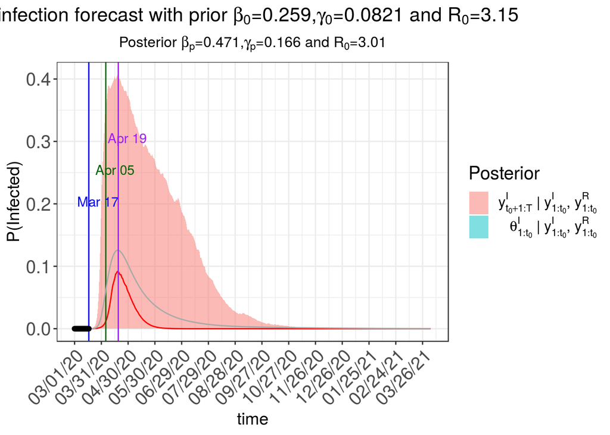

```r
#model with no policy
res.nopolicy <- tvt.eSIR(Y,R,begin_str="03/01/2020",death_in_R = 0.4,T_fin=400,
                     casename="",save_files = F,save_plot_data = F,
                     M=5e3,nburnin = 2e3)
res.nopolicy$plot_infection
```

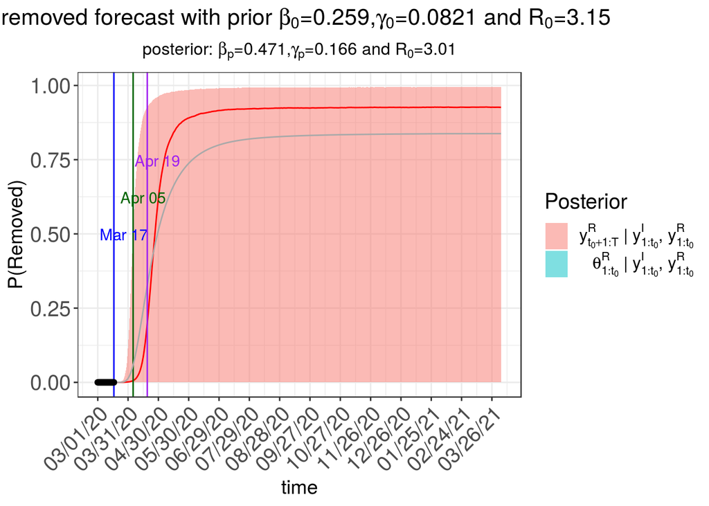

```r
res.nopolicy$plot_removed
```

## 2) Šíření s trvajícím nouzovým stavem omezujícím šíření na 3/4

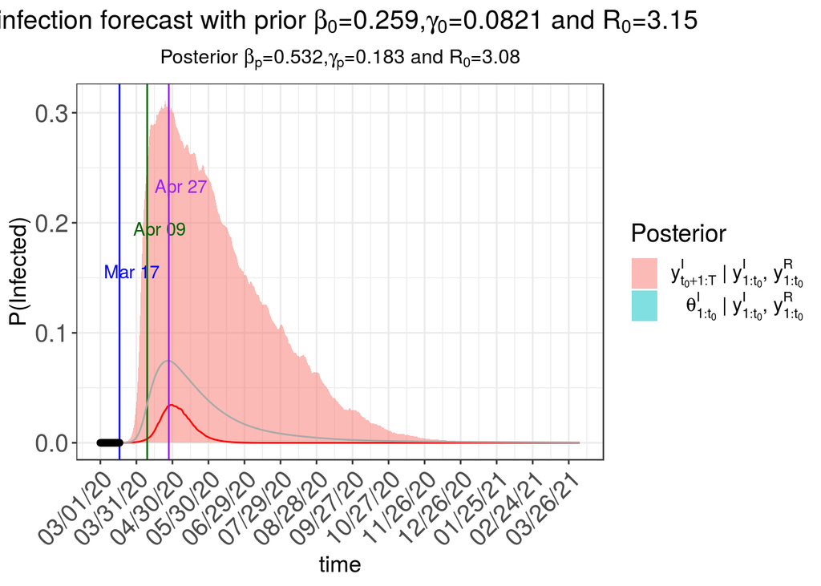

```r
#model with policy continuing from 13th
change_time <- c("03/13/2020")
pi0<- c(1.0,3/4)
res.earlycutoffmild <- tvt.eSIR(Y,R,begin_str="03/01/2020",death_in_R = 0.4,T_fin=400,
                            pi0=pi0,change_time=change_time,dic=T,casename="",
                            save_files = T, save_mcmc=F,save_plot_data = F,M=5e3,nburnin = 2e3)
res.earlycutoffmild$plot_infection
```

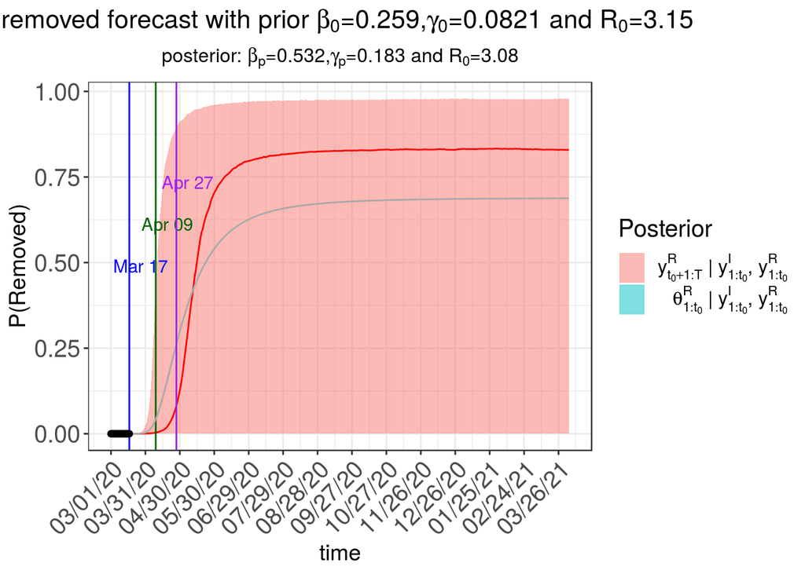

```r
res.earlycutoffmild$plot_removed
```

## 3) Šíření s trvajícím nouzovým stavem omezujícím šíření na 1/4

Nejpravděpodobnější scénář v tomto případě je, že se podaří kontrolovat šíření nákazy s velmi brzkou a daleko mírnější kulminací a velmi nízkým podílem populace, který by nákazu prodělal. Existuje však určitá pravděpodobnost, že ani takto efektivní opatření šíření nákazy nezabrání a počet nakažených dále poroste. Z toho důvodu nám “utíká” průměr predikcí směrem nahoru, tažen několika extrémními hodnotami, byť medián i interval spolehlivosti nakažených zůstávají nízké.

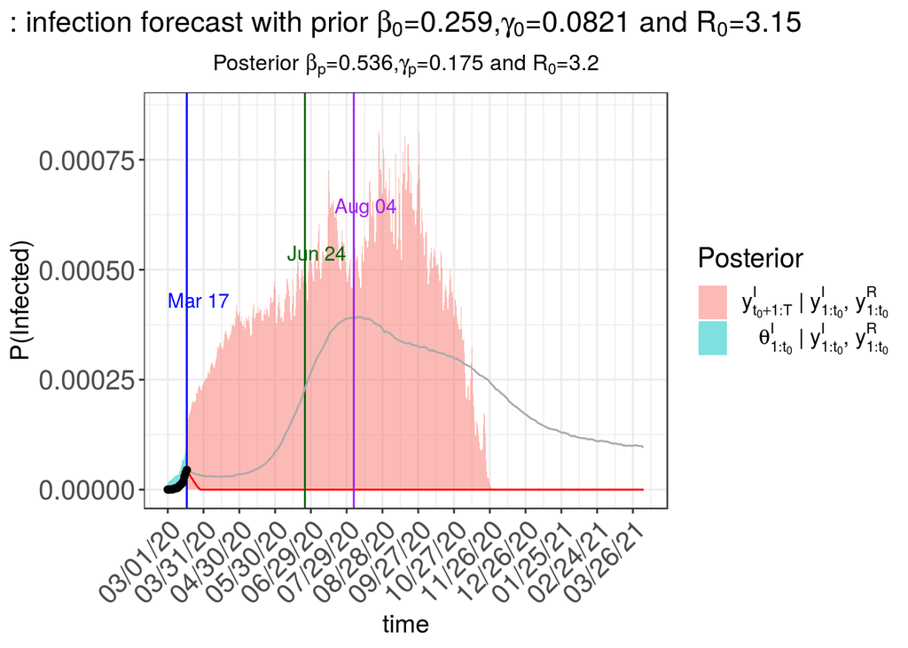

```r
#model with policy continuing from 13th
change_time <- c("03/13/2020")
pi0<- c(1.0,1/4)
res.earlycutoffsevere <- tvt.eSIR(Y,R,begin_str="03/01/2020",death_in_R = 0.4,T_fin=400,
                            pi0=pi0,change_time=change_time,dic=T,casename="",
                            save_files = T, save_mcmc=F,save_plot_data = F,M=5e3,nburnin = 2e3)
res.earlycutoffsevere$plot_infection
```

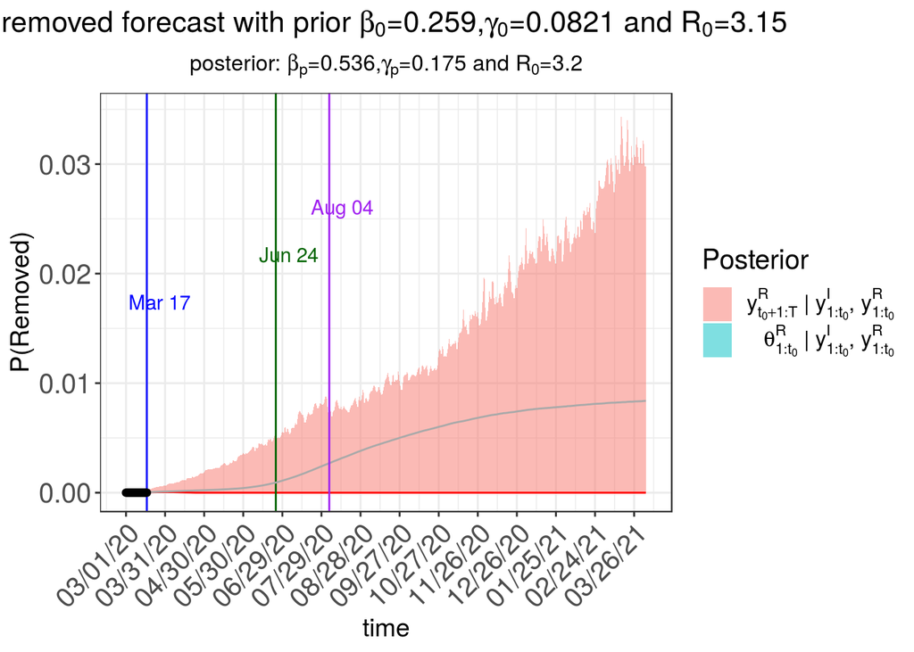

```r
res.earlycutoffsevere$plot_removed
```

## 4) Šíření s nouzovým stavem omezujícím šíření na 1/4 na 1 měsíc

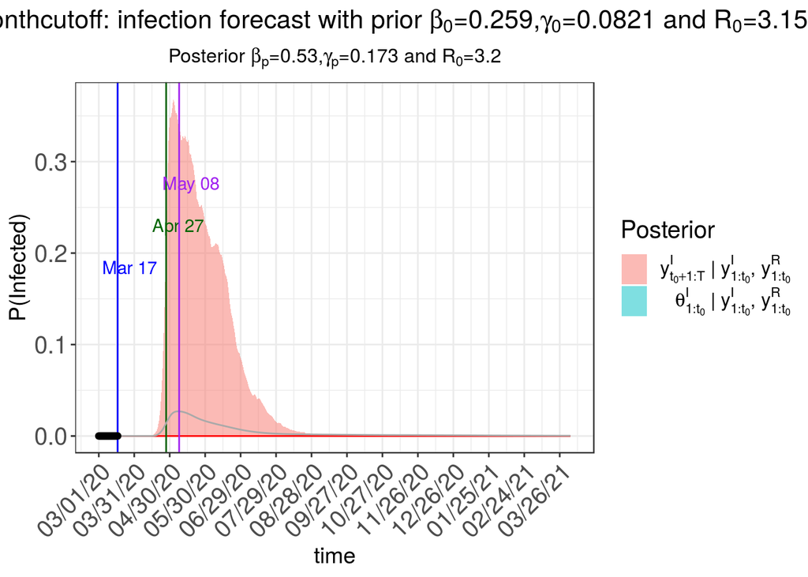

```r
#model with policy continuing from 13th for one month
change_time <- c("03/13/2020", "04/13/20")
pi0<- c(1.0,1/4,1.0)
res.monthcutoff <- tvt.eSIR(Y,R,begin_str="03/01/2020",death_in_R = 0.4,T_fin=400,
                            pi0=pi0,change_time=change_time,dic=T,casename="Czechia_monthcutoff",
                            save_files = T, save_mcmc=F,save_plot_data = F,M=5e3,nburnin = 2e3)
res.monthcutoff$plot_infection
```

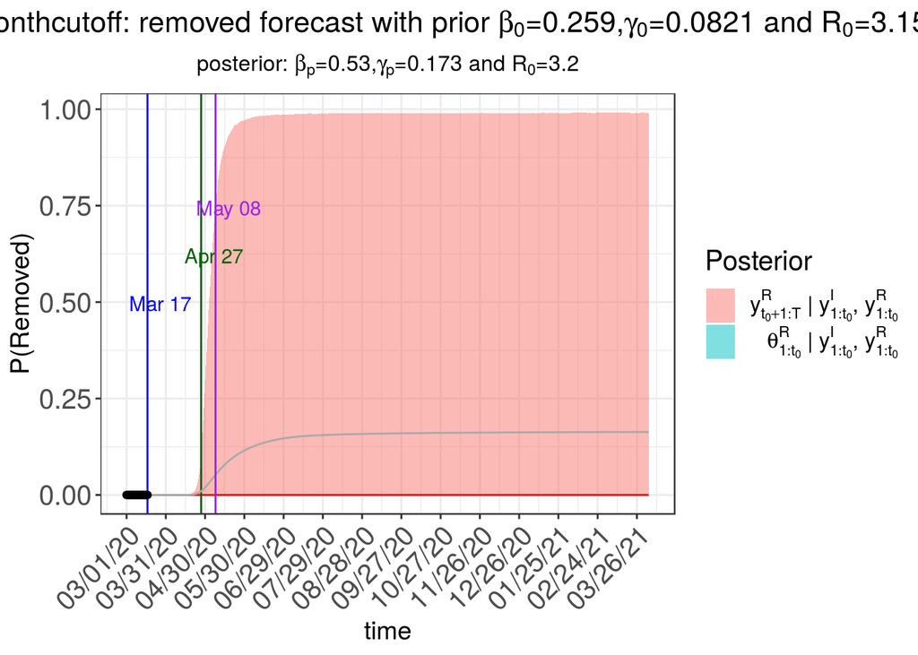

```r
res.monthcutoff$plot_removed
```

## 5) Šíření s nouzovým stavem omezujícím šíření na 1/4 na 3 měsíce

Nejpravděpodobnější průběh je podobný jako u scénáře 4), pouze případný sekundární peak je později a méně pravděpodobný.

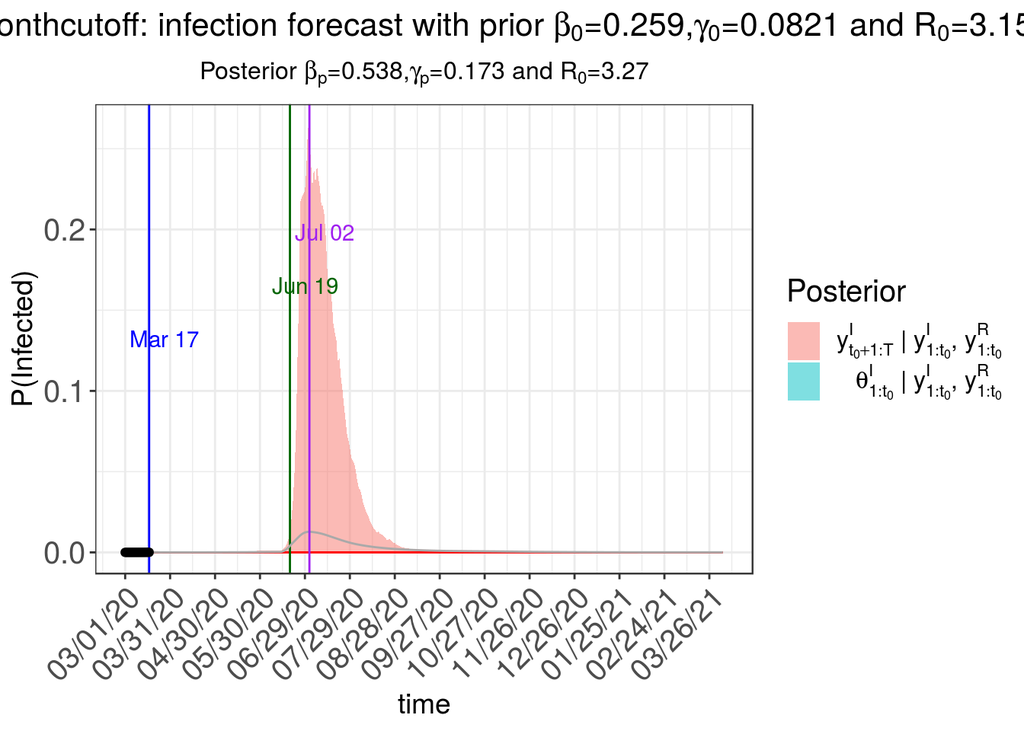

```r
#happy holiday!
change_time <- c("03/13/2020", "06/13/20")
pi0<- c(1.0,1/4,1.0)
res.3monthcutoff <- tvt.eSIR(Y,R,begin_str="03/01/2020",death_in_R = 0.4,T_fin=400,
                            pi0=pi0,change_time=change_time,dic=T,casename="Czechia_3monthcutoff",
                            save_files = T, save_mcmc=F,save_plot_data = F,M=5e3,nburnin = 2e3)
res.3monthcutoff$plot_infection
```

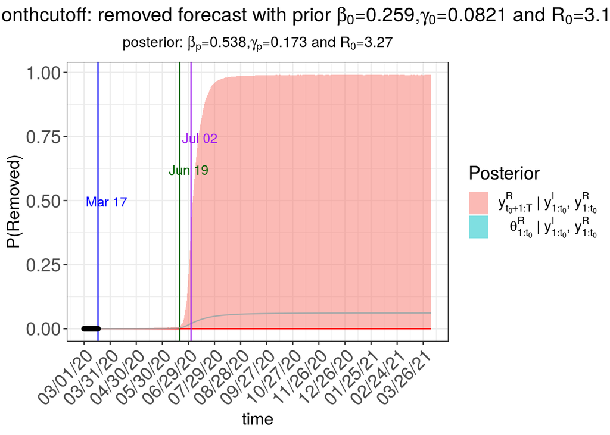

```r
res.3monthcutoff$plot_removed
```

## 6) Šíření s nouzovým stavem omezujícím šíření na 1/4 vypínaným s periodou 1 měsíc

Efektivně jde o velmi podobný scénář jako 4), tedy nouzovému stavu na jeden měsíc. Že dojde při prvním uvolnění k nové kulminaci je méně pravděpodobné, než že nikoliv, ale pokud ano měsíc uvolnění stačí pro našíření do velké části populace.

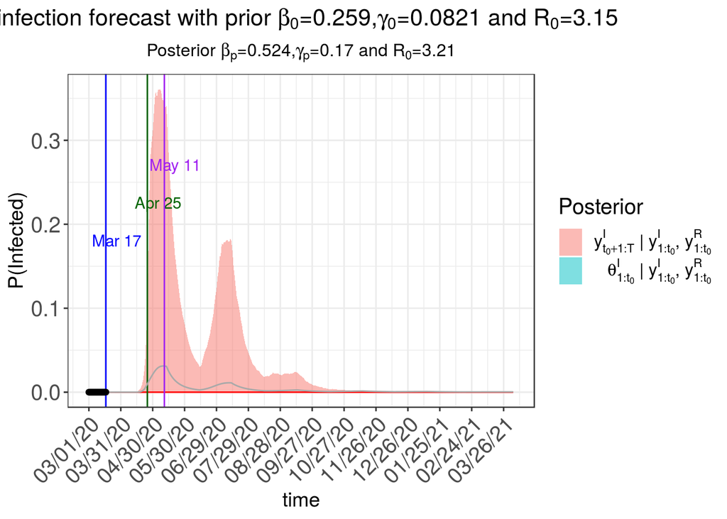

```r
#periodic policy
change_time <- c("03/13/2020", "04/13/20", "05/13/20","06/13/20","07/13/20",
                 "08/13/20", "09/13/20", "10/13/20", "11/13/20", "12/13/20",
                 "01/13/21", "02/13/21")
pi0<- rep(c(1.0,1/4),14)[1:13]
res.periodiccutoff <- tvt.eSIR(Y,R,begin_str="03/01/2020",death_in_R = 0.4,T_fin=400,
                             pi0=pi0,change_time=change_time,dic=T,casename="",
                             save_files = T, save_mcmc=F,save_plot_data = F,M=5e3,nburnin = 2e3)
res.periodiccutoff$plot_infection
```

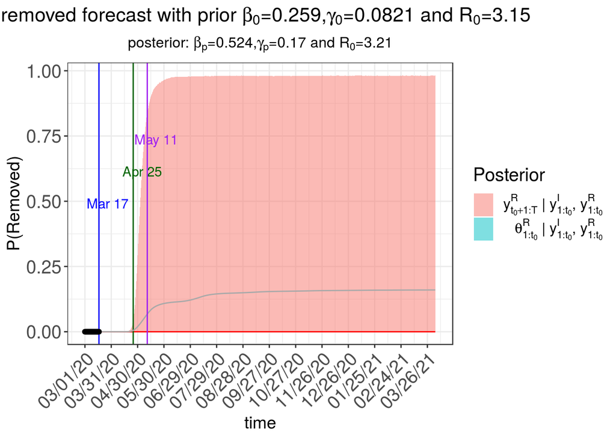

```r
res.periodiccutoff$plot_removed
```

## 7) Šíření s nouzovým stavem omezujícím šíření na 1/4 postupně oslabovaným po dobu 3 měsíců

Stejně jako u scénářů 4-6 je nejpravděpodobnější eradikace nákazy,nicméně je zde určitá pravděpodobnost sekundárního peaku nastupujícího po oslabení opatření na 3/4.

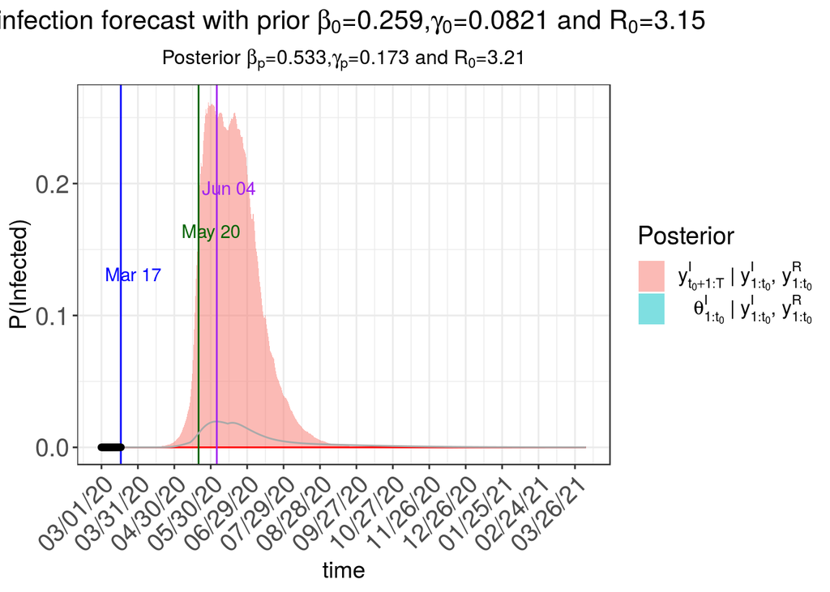

```r
#fadeout
change_time <- c("03/13/2020", "04/13/20", "05/13/20","06/13/20")
pi0<- c(1.0,1/4,1/2,3/4,1)
res.fadeoutcutoff <- tvt.eSIR(Y,R,begin_str="03/01/2020",death_in_R = 0.4,T_fin=400,
                               pi0=pi0,change_time=change_time,dic=T,casename="",
                               save_files = T, save_mcmc=F,save_plot_data = F,M=5e3,nburnin = 2e3)
res.fadeoutcutoff$plot_infection
```

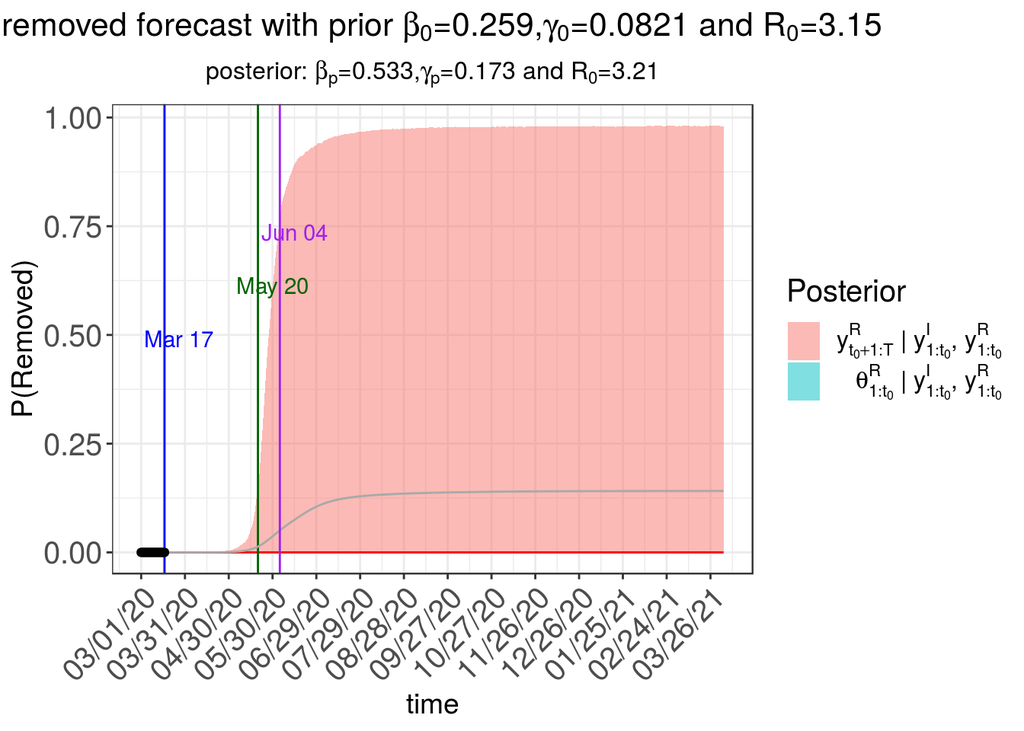

```r
res.fadeoutcutoff$plot_removed
```

## Závěrem

Ve velké většině scénářů se ukazuje, že existuje více různých trajektorií průběhu, z nichž ani jednu nedokážeme vyloučit. Deterministické přístupy však identifikují jen jednu z nich, typicky tu, kterou zde máme reprezentovanou průměrem. Takže s náhodou je potřeba počítat.

## Plány do budoucna (pomoc vítána)

- Překlopit skripty do interaktivní aplikace pomocí nějakého frameworku jako Shiny.
- Použít priory modelu informované šířícími parametry z ostatních zemí.
- Nafitovat model na širší dataset zemí a případně modelovat migraci.
- Modifikovat observační vrstvu tak, aby zohedňovala sampling effort (počet provedených testů).